# Practical Machine Learning

Alok Tripathi

October 23, 2018

## Summary

The goal of this project is to predict the manner in which they did the exercise. This is the “classe” variable in the training set.

```r
library(caret)
library(rattle)
```

## Loading the data

```r
library(RCurl)
```

```r
setInternet2(TRUE)
Train.Data <- read.csv(textConnection(getURL("https://d396qusza40orc.cloudfront.net/predmachlearn/pml-training.csv")))
dim(Train.Data)
```

```
## [1] 19622   160
```

```r
Test.Data <- read.csv(textConnection(getURL("https://d396qusza40orc.cloudfront.net/predmachlearn/pml-testing.csv")))
dim(Test.Data)
```

```
## [1]  20 160
```

```r
str(Train.Data)
```

```
## 'data.frame':    19622 obs. of  160 variables:
##  $ X                       : int  1 2 3 4 5 6 7 8 9 10 ...
##  $ user_name               : Factor w/ 6 levels "adelmo","carlitos",..: 2 2 2 2 2 2 2 2 2 2 ...
##  $ raw_timestamp_part_1    : int  1323084231 1323084231 1323084231 1323084232 1323084232 1323084232 1323084232 1323084232 1323084232 1323084232 ...
##  $ raw_timestamp_part_2    : int  788290 808298 820366 120339 196328 304277 368296 440390 484323 484434 ...
##  $ cvtd_timestamp          : Factor w/ 20 levels "02/12/2011 13:32",..: 9 9 9 9 9 9 9 9 9 9 ...
##  $ new_window              : Factor w/ 2 levels "no","yes": 1 1 1 1 1 1 1 1 1 1 ...
##  $ num_window              : int  11 11 11 12 12 12 12 12 12 12 ...
##  $ roll_belt               : num  1.41 1.41 1.42 1.48 1.48 1.45 1.42 1.42 1.43 1.45 ...
##  $ pitch_belt              : num  8.07 8.07 8.07 8.05 8.07 8.06 8.09 8.13 8.16 8.17 ...
##  $ yaw_belt                : num  -94.4 -94.4 -94.4 -94.4 -94.4 -94.4 -94.4 -94.4 -94.4 -94.4 ...
##  $ total_accel_belt        : int  3 3 3 3 3 3 3 3 3 3 ...
##  $ kurtosis_roll_belt      : Factor w/ 397 levels "","-0.016850",..: 1 1 1 1 1 1 1 1 1 1 ...
##  $ kurtosis_picth_belt     : Factor w/ 317 levels "","-0.021887",..: 1 1 1 1 1 1 1 1 1 1 ...
##  $ kurtosis_yaw_belt       : Factor w/ 2 levels "","#DIV/0!": 1 1 1 1 1 1 1 1 1 1 ...
```

[output cut: 86 more lines]

The training data set is made of 19622 observations on 160 columns. We can notice that many columns have NA values or blank values on almost every observation. So we will remove them, because they will not produce any information. The first seven columns give information about the people who did the test, and also timestamps. We will not take them in our model.

```r
ColToRemove <- which(colSums(is.na(Train.Data) |Train.Data=="")>0.9*dim(Train.Data)[1])
TrainDataClean <- Train.Data[,-ColToRemove]
TrainDataClean <- TrainDataClean[,-c(1:7)]
dim(TrainDataClean)
```

```
## [1] 19622    53
```

```r
ColToRemove <- which(colSums(is.na(Test.Data) |Test.Data=="")>0.9*dim(Test.Data)[1])
TestDataClean <- Test.Data[,-ColToRemove]
TestDataClean <- TestDataClean[,-1]
dim(TestDataClean)
```

```
## [1] 20 59
```

After cleaning, the new training data set has only 53 columns.

```r
set.seed(12345)
inTrain1 <- createDataPartition(TrainDataClean$classe, p=0.75, list=FALSE)
Train1 <- TrainDataClean[inTrain1,]
Test1 <- TrainDataClean[-inTrain1,]
dim(Train1)
```

```
## [1] 14718    53
```

```r
dim(Test1)
```

```
## [1] 4904   53
```

We will test 3 different models : * Classification Tree * Random Forest * Gradient Boosting

To limit the effects of overfitting, and improve the efficicency of the models, we will use the *cross-validation technique. We will use 5 folds.

# Train with Classification Tree

[figure not shown]

```r
library(e1071)
library("rpart.plot")
trControl <- trainControl(method="cv", number=5)
model_CT <- train(classe~., data=Train1, method="rpart", trControl=trControl)
fancyRpartPlot(model_CT$finalModel)
```

```r
trainpred <- predict(model_CT,newdata=Test1)

confMatCT <- confusionMatrix(Test1$classe,trainpred)

# display confusion matrix and model accuracy
confMatCT$table
```

```
##           Reference
## Prediction   A   B   C   D   E
##          A 870 159 273  88   5
##          B 162 530 214  43   0
##          C  29  36 674 116   0
##          D  46 136 429 193   0
##          E  16 221 224  51 389
```

```r
confMatCT$overall[1]
```

```
##  Accuracy
## 0.5415987
```

We can notice that the accuracy of this first model is very low (about 55%). This means that the outcome class will not be predicted very well by the other predictors.

# Training with Random Forest

```r
model_RF <- train(classe~., data=Train1, method="rf", trControl=trControl, verbose=FALSE)
```

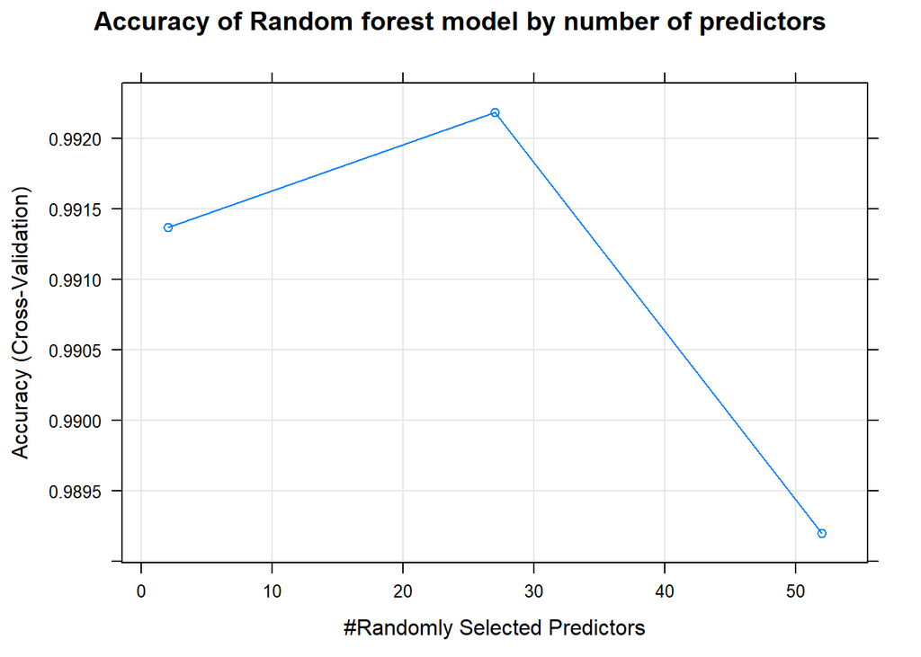

```r
plot(model_RF,main="Accuracy of Random forest model by number of predictors")
```

```r
trainpred <- predict(model_RF,newdata=Test1)

confMatRF <- confusionMatrix(Test1$classe,trainpred)

# display confusion matrix and model accuracy
confMatRF$table
```

```
##           Reference
## Prediction    A    B    C    D    E
##          A 1395    0    0    0    0
##          B    6  939    4    0    0
##          C    0    2  849    4    0
##          D    0    0   11  793    0
##          E    0    0    2    5  894
```

```r
confMatRF$overall[1]
```

```
##  Accuracy
## 0.9930669
```

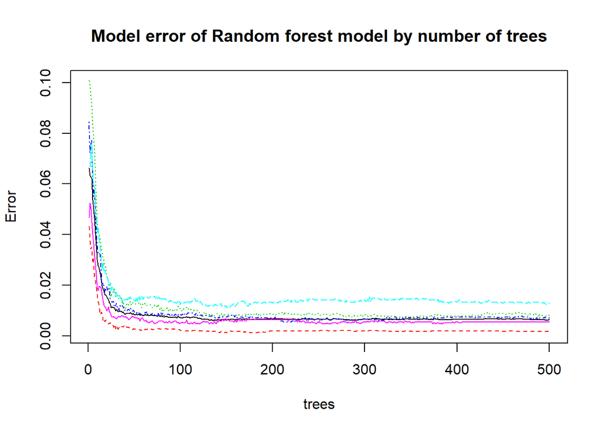

```r
plot(model_RF$finalModel,main="Model error of Random forest model by number of trees")
```

```r
MostImpVars <- varImp(model_RF)
MostImpVars
```

```
## rf variable importance
##
##   only 20 most important variables shown (out of 52)
##
##                      Overall
## roll_belt             100.00
## pitch_forearm          58.88
## yaw_belt               57.19
## magnet_dumbbell_z      44.11
## pitch_belt             43.90
## magnet_dumbbell_y      41.36
## roll_forearm           39.75
## accel_dumbbell_y       21.74
## magnet_dumbbell_x      18.26
## roll_dumbbell          17.90
## accel_forearm_x        17.04
## magnet_belt_z          15.16
## accel_dumbbell_z       15.01
## accel_belt_z           13.94
## magnet_forearm_z       13.86
## total_accel_dumbbell   12.18
## magnet_belt_y          12.03
## yaw_arm                10.65
## gyros_belt_z           10.49
## magnet_belt_x          10.15
```

With random forest, we reach an accuracy of 99.3% using cross-validation with 5 steps. This is very good. But let’s see what we can expect with Gradient boosting.

We can also notice that the optimal number of predictors, i.e. the number of predictors giving the highest accuracy, is 27. There is no significal increase of the accuracy with 2 predictors and 27, but the slope decreases more with more than 27 predictors (even if the accuracy is still very good). The fact that not all the accuracy is worse with all the available predictors lets us suggest that there may be some dependencies between them.

## Training with Gradient boosting

```r
model_GBM <- train(classe~., data=Train1, method="gbm", trControl=trControl, verbose=FALSE)
```

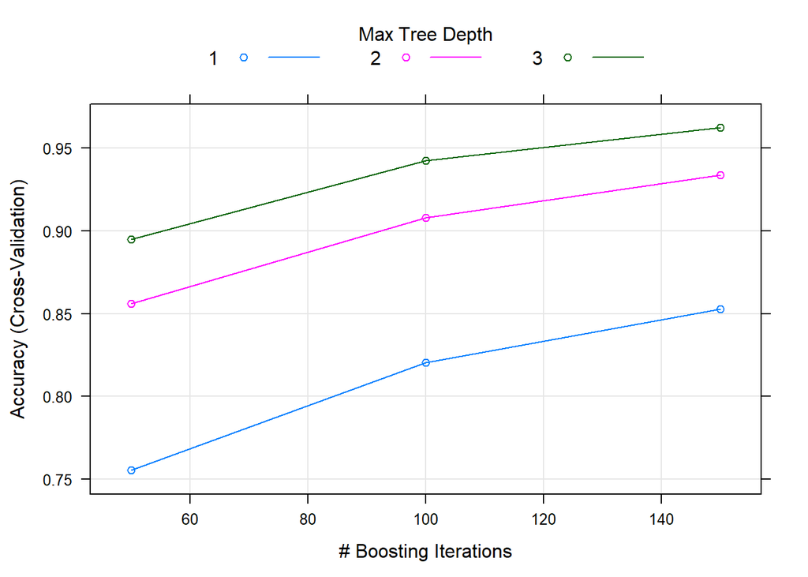

```r
plot(model_GBM)
```

```r
trainpred <- predict(model_GBM,newdata=Test1)

confMatGBM <- confusionMatrix(Test1$classe,trainpred)
confMatGBM$table
```

```
##           Reference
## Prediction    A    B    C    D    E
##          A 1377   13    5    0    0
##          B   42  874   30    3    0
##          C    0   16  824   13    2
##          D    0    4   32  765    3
##          E    3   10   10   15  863
```

```r
confMatGBM$overall[1]
```

```
##  Accuracy
## 0.9590131
```

Precision with 5 folds is 95.9%.

## Conclusion

This shows that the random forest model is the best one. We will then use it to predict the values of classe for the test data set.

```r
FinalTestPred <- predict(model_RF,newdata=TestDataClean)
FinalTestPred
```

```
##  [1] B A B A A E D B A A B C B A E E A B B B
## Levels: A B C D E
```